# Final Assessment Practical Machine Learning

## Reading in the data

First we load caret and read in the data.

```r
library(caret);
setwd("C:/Users/constantin/dat/projekte/DataScience/DataScienceSpec/practlearning/wd");
dftrain<-read.csv("pml-training.csv");
dftest<-read.csv("pml-testing.csv");
```

## Slicing the Data for Cross-Validation

We decide to silce the data in 5 junks for using later cross-validation.

```r
folds<-createFolds(y=dftrain$classe,k=5,list=TRUE, returnTrain=TRUE)
```

## First try: Using all Features and ignoring “Time”-Aspect

So our first approach is to ignore the “time” aspect. This means we do not take features in account, that say something about the time, when the record was recorded.Besides this we want to consider all “physical” features that could help us, predicting later the “classe”-Variable of the “test”-Dataset. (We only take features into account, that are filled and have not an “NA”-Column in the test dataset.)

```r
formula<-classe~roll_belt+pitch_belt+yaw_belt+total_accel_belt+gyros_belt_x+gyros_belt_y+gyros_belt_z+accel_belt_x+
accel_belt_y+accel_belt_z+magnet_belt_x+magnet_belt_y+magnet_belt_z+roll_arm+pitch_arm+yaw_arm+total_accel_arm+
gyros_arm_x+gyros_arm_y+gyros_arm_z+accel_arm_x+accel_arm_y+accel_arm_z+magnet_arm_x+magnet_arm_y+magnet_arm_z+
roll_dumbbell+pitch_dumbbell+yaw_dumbbell+total_accel_dumbbell+gyros_dumbbell_x+gyros_dumbbell_y+gyros_dumbbell_z+
accel_dumbbell_x+accel_dumbbell_y+accel_dumbbell_z+magnet_dumbbell_x+magnet_dumbbell_y+magnet_dumbbell_z+roll_forearm+
pitch_forearm+yaw_forearm+total_accel_forearm+gyros_forearm_x+gyros_forearm_y+gyros_forearm_z+accel_forearm_x+accel_forearm_y+
accel_forearm_z+magnet_forearm_x+magnet_forearm_y+magnet_forearm_z

countOfSamples<-0
right<-0
for(i in 1:length(folds)){

  train<-dftrain[folds[[i]],]
  test<-dftrain[-folds[[i]],]

  countOfSamples<-countOfSamples+dim(test)[1]
  modfit<-train(formula,method="rpart",data=train)
  ergs<-predict(modfit,test)
  right<-right+sum(ergs==test$classe)


}

print("Correctly predicted:")
```

```
## [1] "Correctly predicted:"
```

```r
print(right)
```

```
## [1] 9717
```

```r
print("Total Amount:")
```

```
## [1] "Total Amount:"
```

```r
print(countOfSamples)
```

```
## [1] 19622
```

```r
print("Accuracy:")
```

```
## [1] "Accuracy:"
```

```r
print(right/countOfSamples)
```

```
## [1] 0.4952095
```

The Accuracy is about 0.5. That is not really good.

## Second try: Taking time especially the “num_window” feature into account.

Because our first try was not really successful, we decide to integrate the time aspect. Because the num_window feature is also present in the test-dataset and the instructions allow us really to use all features to predict the classe-Variable, we will integrate it in our model.

First take a look at the relation between “num_window” and “classe”:

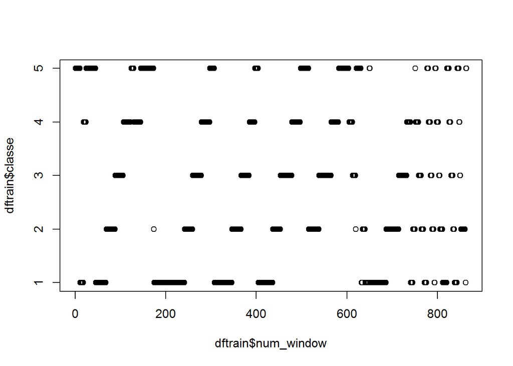

```r
plot(dftrain$num_window,dftrain$classe)
```

So the lines hardly ever do overlap. That is a good sign. But to concenctrate its information, we create some self-defined features. We will count the different classes for each “num_window” and create some Indicator features, that will indicate if a certain classe is the most recent for this “num_window”.

```r
mostRecent<-function(x){
  names(sort(table(x),decreasing = TRUE))[1]
}

genWindowModel <-function(data){

   classeAWindows<-c()
   classeBWindows<-c()
   classeCWindows<-c()
   classeDWindows<-c()
   classeEWindows<-c()

   windows<-unique(data$num_window)

   for(window in windows){
     mostRecentClass<-mostRecent(data[data$num_window==window,]$classe)

      if(mostRecentClass=="A"){
        classeAWindows<-c(classeAWindows,window)
      }

     if(mostRecentClass=="B"){
       classeBWindows<-c(classeBWindows,window)
     }

     if(mostRecentClass=="C"){
       classeCWindows<-c(classeCWindows,window)
     }

     if(mostRecentClass=="D"){
       classeDWindows<-c(classeDWindows,window)
     }

     if(mostRecentClass=="E"){
       classeEWindows<-c(classeEWindows,window)
     }

   }

   list(classeAWindows,
        classeBWindows,
        classeCWindows,
        classeDWindows,
        classeEWindows)

}

addFeatures <- function(model, data){
    l<-dim(data)[1]
    data$classeAIndicator<-0*l
    data$classeBIndicator<-0*l
    data$classeCIndicator<-0*l
    data$classeDIndicator<-0*l
    data$classeEIndicator<-0*l

    for(i in 1:l){

      v<-data[i,]$num_window

      if(v %in% model[[1]]){
        data$classeAIndicator[i]<-1
      }

      if(v %in% model[[2]]){
        data$classeBIndicator[i]<-1
      }

      if(v %in% model[[3]]){
        data$classeCIndicator[i]<-1
      }

      if(v %in% model[[4]]){
        data$classeDIndicator[i]<-1
      }

      if(v %in% model[[5]]){
        data$classeEIndicator[i]<-1
      }

    }

    data
}
```

We now add this features to our model and use cross validation to determine the expected error-rate:

```r
formula<-classe~roll_belt+pitch_belt+yaw_belt+total_accel_belt+gyros_belt_x+gyros_belt_y+gyros_belt_z+accel_belt_x+
  accel_belt_y+accel_belt_z+magnet_belt_x+magnet_belt_y+magnet_belt_z+roll_arm+pitch_arm+yaw_arm+total_accel_arm+
  gyros_arm_x+gyros_arm_y+gyros_arm_z+accel_arm_x+accel_arm_y+accel_arm_z+magnet_arm_x+magnet_arm_y+magnet_arm_z+
  roll_dumbbell+pitch_dumbbell+yaw_dumbbell+total_accel_dumbbell+gyros_dumbbell_x+gyros_dumbbell_y+gyros_dumbbell_z+
  accel_dumbbell_x+accel_dumbbell_y+accel_dumbbell_z+magnet_dumbbell_x+magnet_dumbbell_y+magnet_dumbbell_z+roll_forearm+
  pitch_forearm+yaw_forearm+total_accel_forearm+gyros_forearm_x+gyros_forearm_y+gyros_forearm_z+accel_forearm_x+accel_forearm_y+accel_forearm_z+magnet_forearm_x+magnet_forearm_y+magnet_forearm_z+classeAIndicator+classeBIndicator+classeCIndicator+classeDIndicator+classeEIndicator

options(warn=-1)

countOfSamples<-0
right<-0
for(i in 1:length(folds)){

  train<-dftrain[folds[[i]],]
  test<-dftrain[-folds[[i]],]

  countOfSamples<-countOfSamples+dim(test)[1]

  windowModel<-genWindowModel(train)
  train<-addFeatures(windowModel,train)
  test<-addFeatures(windowModel,test)

  modfit<-train(formula,method="rpart",data=train)
  ergs<-predict(modfit,test)
  right<-right+sum(ergs==test$classe)

}

print("Correctly predicted:")
```

```
## [1] "Correctly predicted:"
```

```r
print(right)
```

```
## [1] 12983
```

```r
print("Total Amount:")
```

```
## [1] "Total Amount:"
```

```r
print(countOfSamples)
```

```
## [1] 19622
```

```r
print("Accuracy:")
```

```
## [1] "Accuracy:"
```

```r
print(right/countOfSamples)
```

```
## [1] 0.6616553
```

So the accuracy is about 0.66 and quite better, but not good enough.

## One more try: Using Linear Regression (instead of bagging and boosting) to optimize the accuracy

We could try to use bagging and boosting for optimizing our model. But we want to give another approach a try. We convert the “classe”-Variable into a Numeric-Variable and try to predict it with linear regression. First we write some functions to convert from factor to numeric and vice versa:

```r
addConvertClassToNumeric <- function(data){
  l<-dim(data)[1]
  data$classeNum<-0*l

  for(i in 1:l){

    v<-data[i,]$classe

    if(v =="A"){
      data$classeNum[i]<-1
    }

    if(v =="B"){
      data$classeNum[i]<-2
    }

    if(v =="C"){
      data$classeNum[i]<-3
    }

    if(v =="D"){
      data$classeNum[i]<-4
    }

    if(v =="E"){
      data$classeNum[i]<-5
    }
  }

  data
}

convertNumericToClass <- function(vec){
  l<-length(vec)
  result<-c()

  for(i in 1:l){

    if(vec[i] ==1){
      result[i]<-"A"
    }
    if(vec[i] ==2){
      result[i]<-"B"
    }
    if(vec[i] ==3){
      result[i]<-"C"
    }
    if(vec[i] ==4){
      result[i]<-"D"
    }
    if(vec[i] ==5){
      result[i]<-"E"
    }

  }

  factor(x=result,levels=c("A","B","C","D","E"))
}
```

No we use cross validation again to evaluate the model:

```r
formula<-classeNum~roll_belt+pitch_belt+yaw_belt+total_accel_belt+gyros_belt_x+gyros_belt_y+gyros_belt_z+accel_belt_x+
  accel_belt_y+accel_belt_z+magnet_belt_x+magnet_belt_y+magnet_belt_z+roll_arm+pitch_arm+yaw_arm+total_accel_arm+
  gyros_arm_x+gyros_arm_y+gyros_arm_z+accel_arm_x+accel_arm_y+accel_arm_z+magnet_arm_x+magnet_arm_y+magnet_arm_z+
  roll_dumbbell+pitch_dumbbell+yaw_dumbbell+total_accel_dumbbell+gyros_dumbbell_x+gyros_dumbbell_y+gyros_dumbbell_z+
  accel_dumbbell_x+accel_dumbbell_y+accel_dumbbell_z+magnet_dumbbell_x+magnet_dumbbell_y+magnet_dumbbell_z+roll_forearm+
  pitch_forearm+yaw_forearm+total_accel_forearm+gyros_forearm_x+gyros_forearm_y+gyros_forearm_z+accel_forearm_x+accel_forearm_y+accel_forearm_z+magnet_forearm_x+magnet_forearm_y+magnet_forearm_z+classeAIndicator+classeBIndicator+classeCIndicator+classeDIndicator+classeEIndicator

countOfSamples<-0
right<-0
for(i in 1:length(folds)){

  train<-dftrain[folds[[i]],]
  test<-dftrain[-folds[[i]],]

  countOfSamples<-countOfSamples+dim(test)[1]

  windowModel<-genWindowModel(train)
  train<-addFeatures(windowModel,train)
  train<-addConvertClassToNumeric(train)
  test<-addFeatures(windowModel,test)
  test<-addConvertClassToNumeric(test)

  modfit<-train(formula,method="lm",data=train)
  ergs<-predict(modfit,test)
  right<-right+sum(round(ergs)==test$classeNum)

}

print("Correctly predicted:")
```

```
## [1] "Correctly predicted:"
```

```r
print(right)
```

```
## [1] 19617
```

```r
print("Total Amount:")
```

```
## [1] "Total Amount:"
```

```r
print(countOfSamples)
```

```
## [1] 19622
```

```r
print("Accuracy:")
```

```
## [1] "Accuracy:"
```

```r
print(right/countOfSamples)
```

```
## [1] 0.9997452
```

That looks better !

## Final Application to Test-Set

```r
formula<-classeNum~roll_belt+pitch_belt+yaw_belt+total_accel_belt+gyros_belt_x+gyros_belt_y+gyros_belt_z+accel_belt_x+
  accel_belt_y+accel_belt_z+magnet_belt_x+magnet_belt_y+magnet_belt_z+roll_arm+pitch_arm+yaw_arm+total_accel_arm+
  gyros_arm_x+gyros_arm_y+gyros_arm_z+accel_arm_x+accel_arm_y+accel_arm_z+magnet_arm_x+magnet_arm_y+magnet_arm_z+
  roll_dumbbell+pitch_dumbbell+yaw_dumbbell+total_accel_dumbbell+gyros_dumbbell_x+gyros_dumbbell_y+gyros_dumbbell_z+
  accel_dumbbell_x+accel_dumbbell_y+accel_dumbbell_z+magnet_dumbbell_x+magnet_dumbbell_y+magnet_dumbbell_z+roll_forearm+
  pitch_forearm+yaw_forearm+total_accel_forearm+gyros_forearm_x+gyros_forearm_y+gyros_forearm_z+accel_forearm_x+accel_forearm_y+
  accel_forearm_z+magnet_forearm_x+magnet_forearm_y+magnet_forearm_z+classeAIndicator+classeBIndicator+classeCIndicator+classeDIndicator+classeEIndicator

countOfSamples<-0
right<-0

train<-dftrain
test<-dftest

windowModel<-genWindowModel(train)
train<-addFeatures(windowModel,train)
train<-addConvertClassToNumeric(train)
test<-addFeatures(windowModel,test)


modfit<-train(formula,method="lm",data=train)
ergs<-predict(modfit,test)

print(convertNumericToClass(round(ergs)))
```

```
##  [1] B A B A A E D B A A B C B A E E A B B B
## Levels: A B C D E
```

Filling out the prediction quizz we find out, that our accuracy is 100%.

## Summary

Depending on, if we include the “time”-aspect or not, our accuracy for predicting an out sample record will be between 0.5 and 1.0.